# Zadania7

Szymon Szrajer

13 05 2021

## Zadanie 1

**Hipoteza robocza:**  
Stężenie tanin wpływa na tempo wzrostu larw motyla.  
**Hipoteza zerowa:**  
Stężenie tanin nie wpływa na tempo wzrostu larw motyla.  
**Hipoteza alternatywna:**  
Stężenie tanin wpływa na tempo wzrostu larw motyla.  
**Testy “z wyboru”:**  
Analiza regresji.  
**Założenia teoretycznie dotyczące rozkładu wymagane dla wybranego testu:**  
Reszty mają rozkład zbliżony do rozkładu normalnego, liniowa zależność, równość wariancji.

```r
taniny <- read.table(file = "Tannins.txt",
                        sep = "\t",
                        header = T,
                        stringsAsFactors = T)

shapiro.test(taniny$LM)
```

```
##
##  Shapiro-Wilk normality test
##
## data:  taniny$LM
## W = 0.9291, p-value = 0.4728
```

```r
summary(taniny)
```

```
##      Index         TC          LM
##  Min.   :1   Min.   :0   Min.   : 2.000
##  1st Qu.:3   1st Qu.:2   1st Qu.: 3.000
##  Median :5   Median :4   Median : 7.000
##  Mean   :5   Mean   :4   Mean   : 6.889
##  3rd Qu.:7   3rd Qu.:6   3rd Qu.:10.000
##  Max.   :9   Max.   :8   Max.   :12.000
```

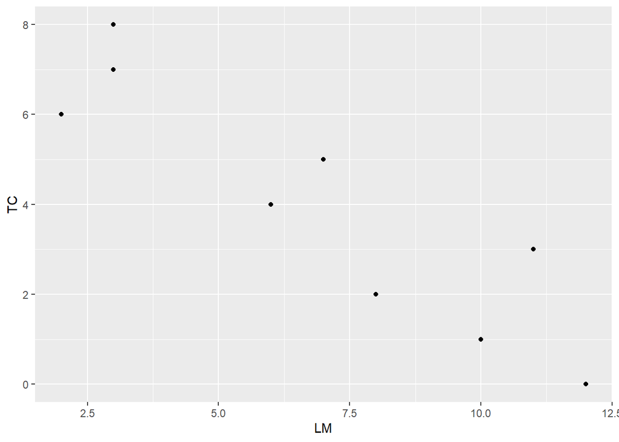

```r
model_ggplot <- ggplot(data= taniny, aes(x = LM , y = TC))+ geom_point()
plot(model_ggplot)
```

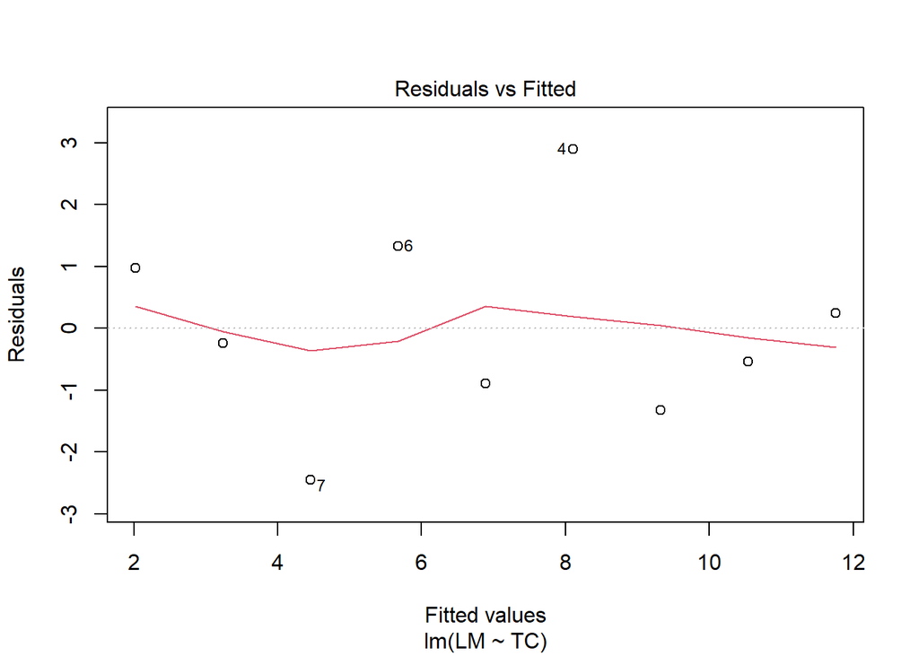

```r
model <- lm(LM~TC, taniny)
plot(model,1)
```

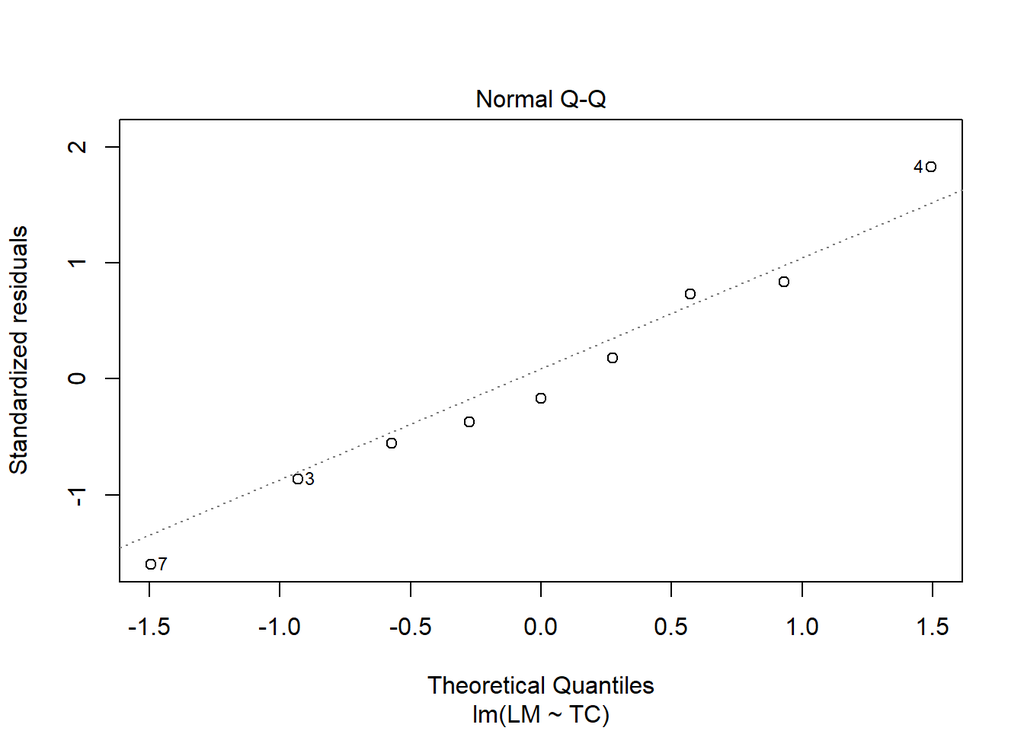

```r
plot(model,2)
```

```r
summary(model)
```

```
##
## Call:
## lm(formula = LM ~ TC, data = taniny)
##
## Residuals:
##     Min      1Q  Median      3Q     Max
## -2.4556 -0.8889 -0.2389  0.9778  2.8944
##
## Coefficients:
##             Estimate Std. Error t value Pr(>|t|)
## (Intercept)  11.7556     1.0408  11.295 9.54e-06 ***
## TC           -1.2167     0.2186  -5.565 0.000846 ***
## ---
## Signif. codes:  0 '***' 0.001 '**' 0.01 '*' 0.05 '.' 0.1 ' ' 1
##
## Residual standard error: 1.693 on 7 degrees of freedom
## Multiple R-squared:  0.8157, Adjusted R-squared:  0.7893
## F-statistic: 30.97 on 1 and 7 DF,  p-value: 0.0008461
```

**Tabela z analizą wyników, kolejno:**

Rozkład wartości resztowych, współczynniki- wartości dla każdej ze zmiennych: oszacowanie, błąd standardowy, t-value i istotność.

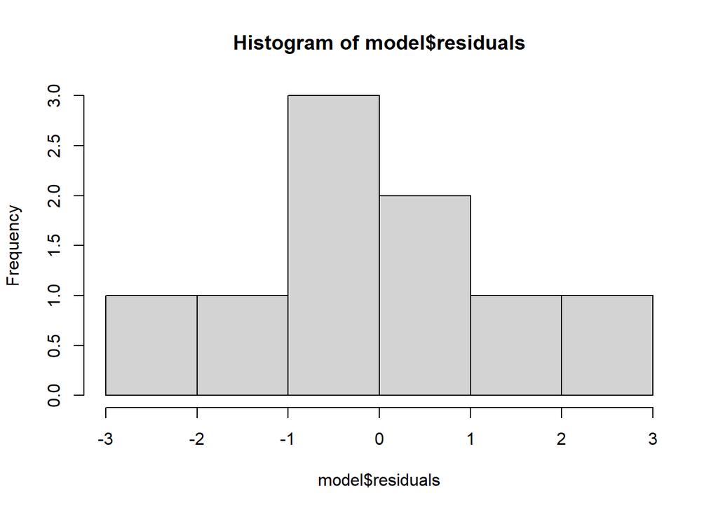

```r
hist(model$residuals)
```

Rodzkład zbliżony do normalnego.  
Wykres przedstawiający wyniki:

```r
summary(taniny)
```

```
##      Index         TC          LM
##  Min.   :1   Min.   :0   Min.   : 2.000
##  1st Qu.:3   1st Qu.:2   1st Qu.: 3.000
##  Median :5   Median :4   Median : 7.000
##  Mean   :5   Mean   :4   Mean   : 6.889
##  3rd Qu.:7   3rd Qu.:6   3rd Qu.:10.000
##  Max.   :9   Max.   :8   Max.   :12.000
```

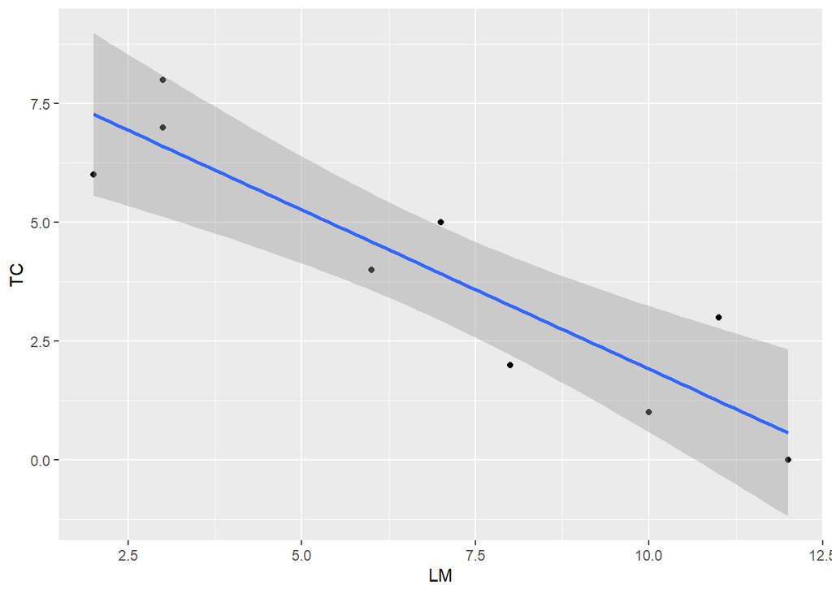

```r
model_ggplot <- ggplot(data= taniny, aes(x = LM , y = TC))+ geom_point() + stat_smooth(method = lm)
plot(model_ggplot)
```

## Zadanie 2

**Hipoteza robocza:**  
1) Spoczynkowe tempo metabolizmu rośnie z masą ciała.  
2) Nachylenie zależności tempa spoczynkowego metabolizmu nie jest zgodne z prawem potęgi 3/4.  
3) Nachylenie zależności tempa spoczynkowego metabolizmu jest zgodne z prawem powierzchni 2/3.

**Hipoteza zerowa:**  
1) Tempo metabolizmu nie rośnie z masą ciała.  
2) Nachylenie zależności tempa spoczynkowego metabolizmu nie jest zgodne z prawem potęgi 3/4.  
3) Nachylenie zależności tempa spoczynkowego metabolizmu nie jest zgodne z prawem powierzchni 2/3.

**Hipoteza alternatywna:**  
1) Tempo metabolizmu rośnie z masą ciała.  
2) Nachylenie zależności tempa spoczynkowego metabolizmu jest zgodne z prawem potęgi 3/4.  
3) Nachylenie zależności tempa spoczynkowego metabolizmu jest zgodne z prawem powierzchni 2/3.

**Testy “z wyboru”:**  
Analiza regresji.

**Założenia teoretyczne:**  
Reszty mają rozkład zbliżony do rozkładu normalnego, liniowa zależność, równość wariancji.

**Dodatkowe założenie**:  
multicollinereality? Jedna z przewidywanych wartosci może być w w sposób przybliżony wyznaczona na podstawie innych.

**Transformacja:** Należy dokonać transformacji logarytmicznej.  
Po transformacji: RMR=a′+b′M.

```r
RMR <- read.table(file = "RMR_Rodents.txt",
                        sep = "\t",
                        header = T,
                        stringsAsFactors = T)
```

**Statystyki opisowe:**

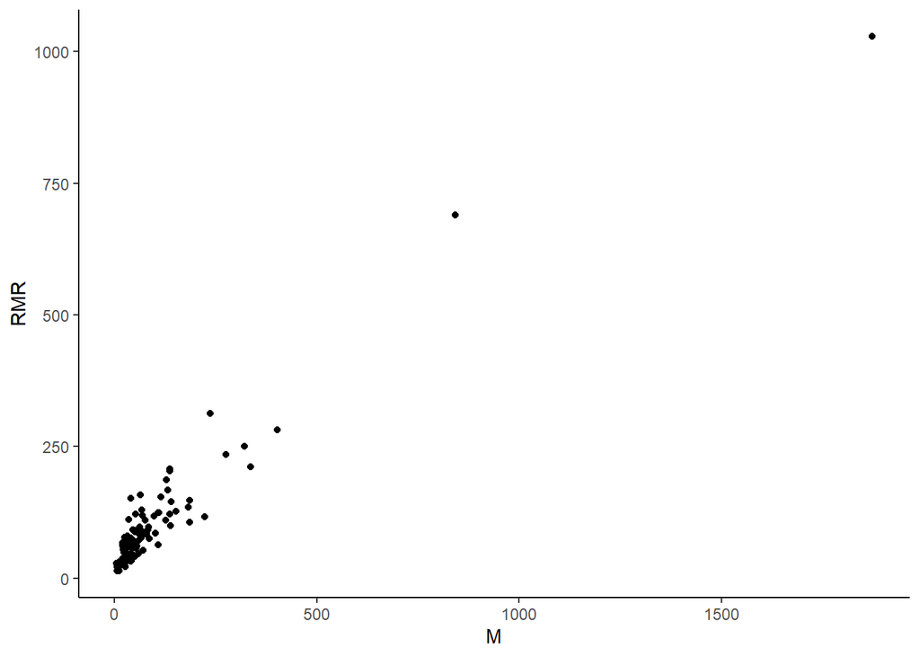

```r
Rgraph <- ggplot(data = RMR, aes(x=M, y = RMR)) + geom_point()  + theme_classic()
Rgraph
```

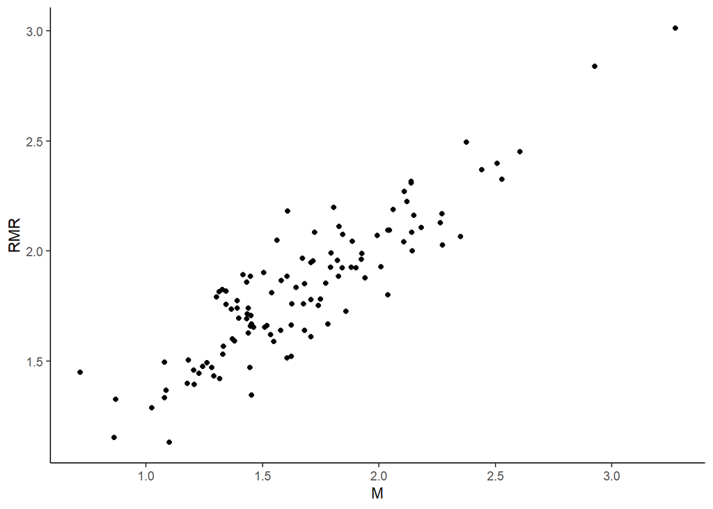

```r
RMR$M <- log10(RMR$M)
RMR$RMR <- log10(RMR$RMR)
Rgraph2 <- ggplot(data = RMR, aes(x=M, y = RMR)) + geom_point()  + theme_classic()
Rgraph2
```

**Testy:**

```r
rodents <- lm(RMR ~ M + offset((2/3)*M), data = RMR)
summary(rodents)
```

```
##
## Call:
## lm(formula = RMR ~ M + offset((2/3) * M), data = RMR)
##
## Residuals:
##      Min       1Q   Median       3Q      Max
## -0.33113 -0.09080 -0.01536  0.09915  0.40068
##
## Coefficients:
##             Estimate Std. Error t value Pr(>|t|)
## (Intercept)  0.69180    0.05503  12.571   <2e-16 ***
## M            0.01156    0.03182   0.363    0.717
## ---
## Signif. codes:  0 '***' 0.001 '**' 0.01 '*' 0.05 '.' 0.1 ' ' 1
##
## Residual standard error: 0.1439 on 112 degrees of freedom
## Multiple R-squared:  0.8022, Adjusted R-squared:  0.8005
## F-statistic: 454.3 on 1 and 112 DF,  p-value: < 2.2e-16
```

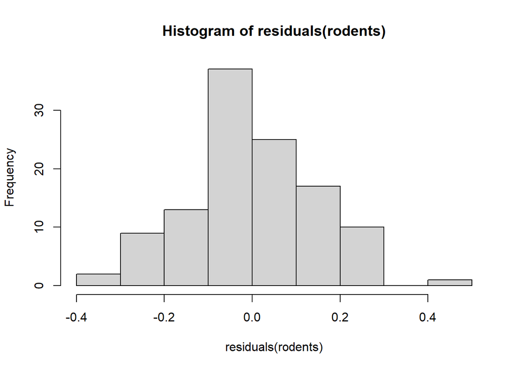

```r
hist(residuals(rodents))
```

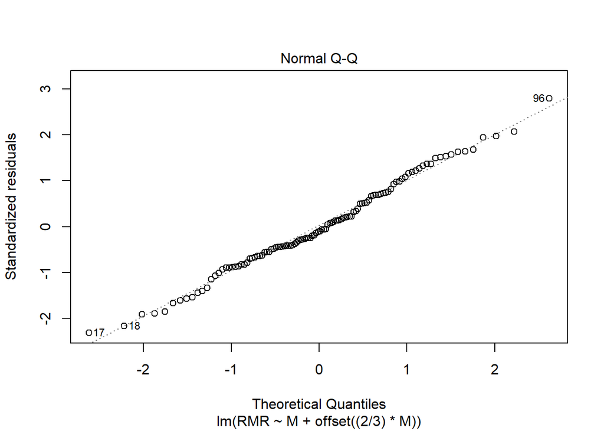

```r
plot(rodents, 2)
```

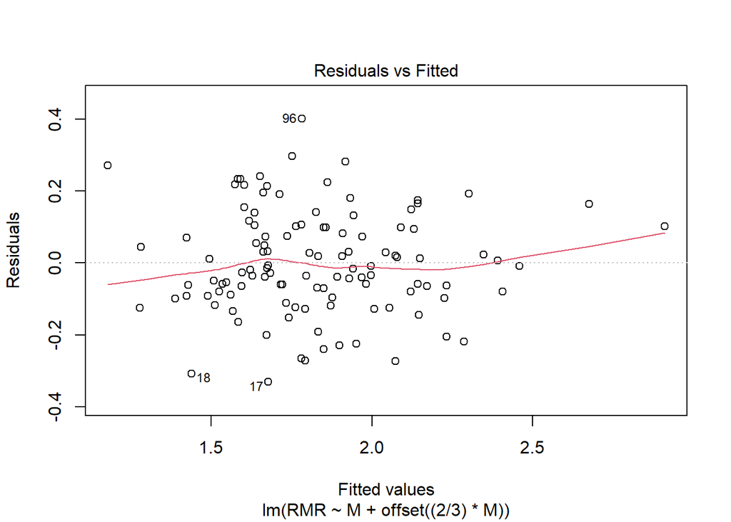

```r
plot(rodents, 1)
```

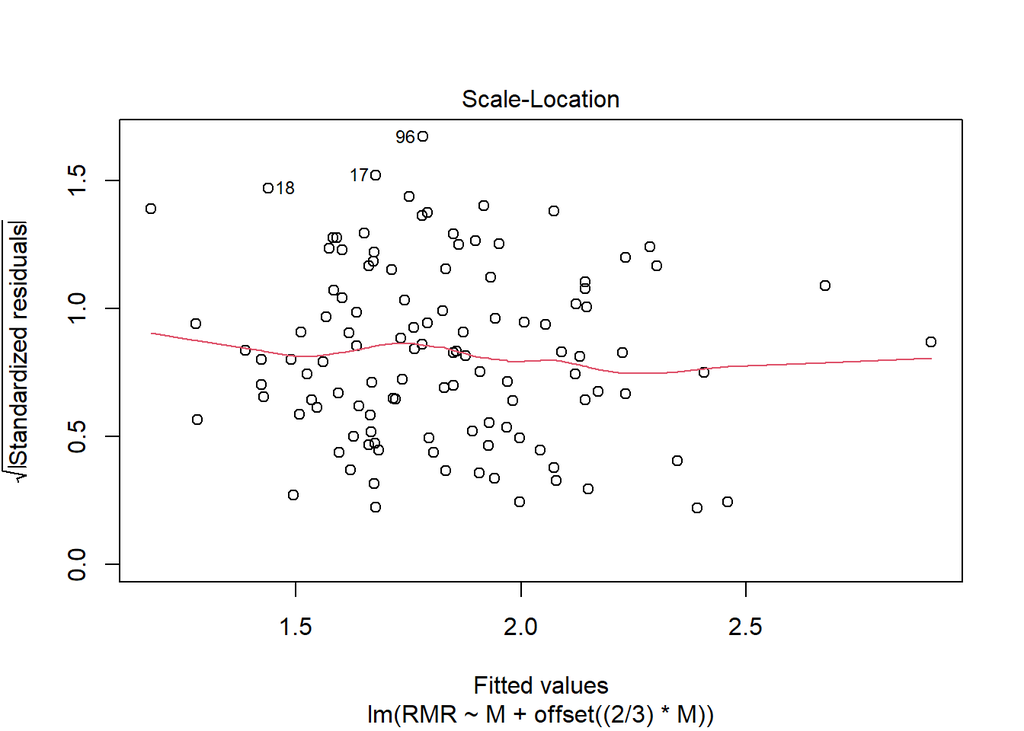

```r
plot(rodents, 3)
```

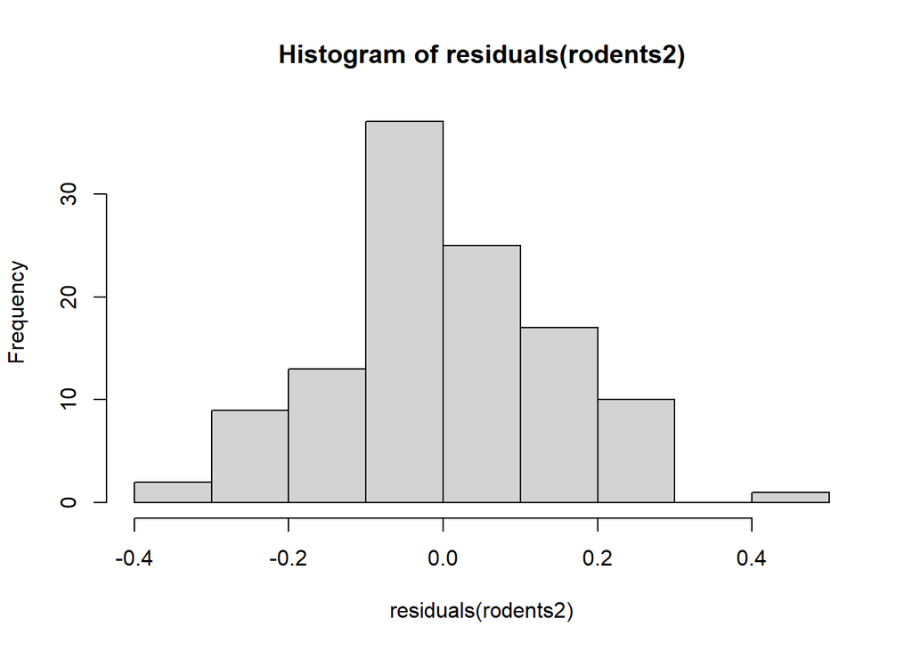

```r
rodents2 <- lm(RMR ~ M + offset((3/4)*M), data = RMR)
hist(residuals(rodents2))
```

```r
summary(rodents2)
```

```
##
## Call:
## lm(formula = RMR ~ M + offset((3/4) * M), data = RMR)
##
## Residuals:
##      Min       1Q   Median       3Q      Max
## -0.33113 -0.09080 -0.01536  0.09915  0.40068
##
## Coefficients:
##             Estimate Std. Error t value Pr(>|t|)
## (Intercept)  0.69180    0.05503  12.571   <2e-16 ***
## M           -0.07177    0.03182  -2.256    0.026 *
## ---
## Signif. codes:  0 '***' 0.001 '**' 0.01 '*' 0.05 '.' 0.1 ' ' 1
##
## Residual standard error: 0.1439 on 112 degrees of freedom
## Multiple R-squared:  0.8022, Adjusted R-squared:  0.8005
## F-statistic: 454.3 on 1 and 112 DF,  p-value: < 2.2e-16
```

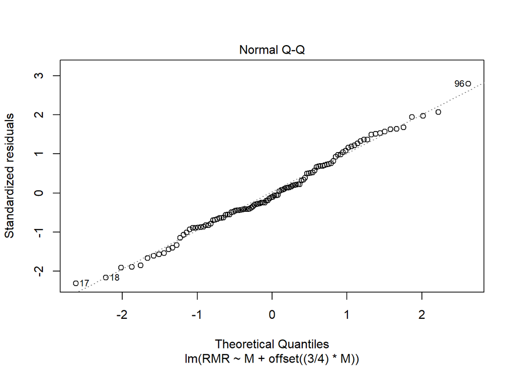

```r
plot(rodents2, 2)
```

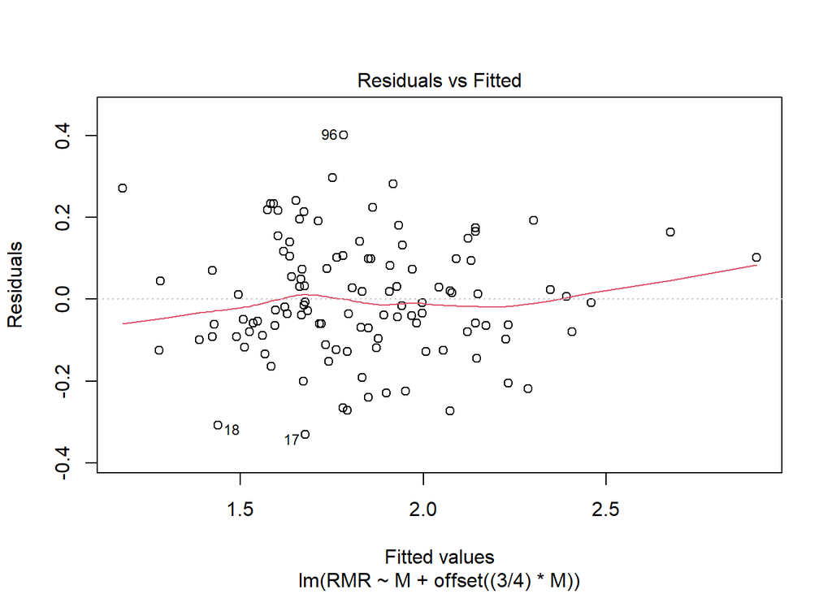

```r
plot(rodents2, 1)
```

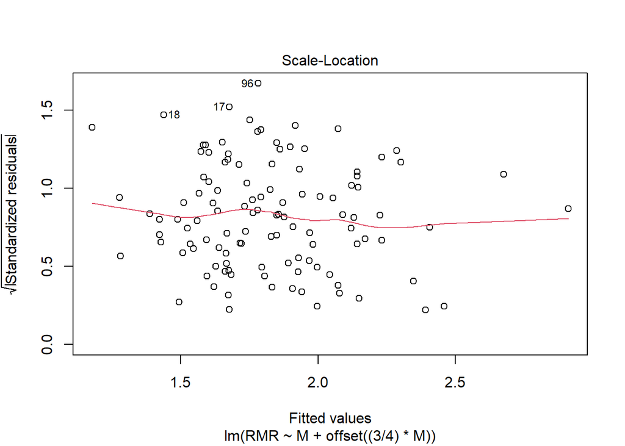

```r
plot(rodents2, 3)
```

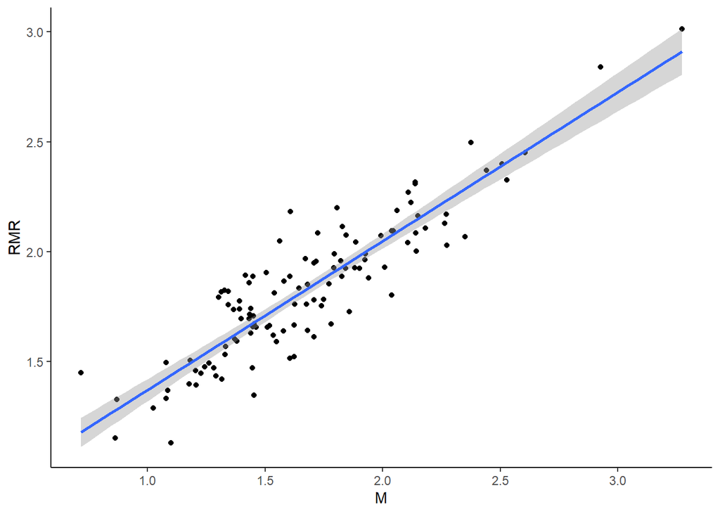

```r
Result <- ggplot(data = RMR, aes(x=M, y = RMR)) + geom_point()  + theme_classic() + stat_smooth(method = lm)
Result
```

## Zadanie 3

**Hipoteza robocza:**  
Pozycja w rankingu dominacji małp jest związana ze stopniem zapasożycenia.  
**Hipoteza zerowa:**  
Pozycja w rankingu dominacji małp nie jest związana ze stopniem zapasożycenia.  
**Hipoteza alternatywna:**  
Pozycja w rankingu dominacji małp jest związana ze stopniem zapasożycenia.  
**Testy “z wyboru”:**  
Analiza korelacji.  
**Założenia teoretycznie dotyczące rozkładu wymagane dla wybranego testu:**  
Reszty mają rozkład zbliżony do rozkładu normalnego, liniowa zależność, równość wariancji.

```r
monke <- read.table(file = "Monkeys.txt",
                        sep = "\t",
                        header = T,
                        stringsAsFactors = T)
monke
```

```
##   Nr  Name DomRank Eggs
## 1  1  Alfa       1 5777
## 2  2  Beta       2 1625
## 3  3 Gamma       3 1174
## 4  4 Delta       4  949
## 5  5 Theta       5  749
## 6  6 Omega       6  870
```

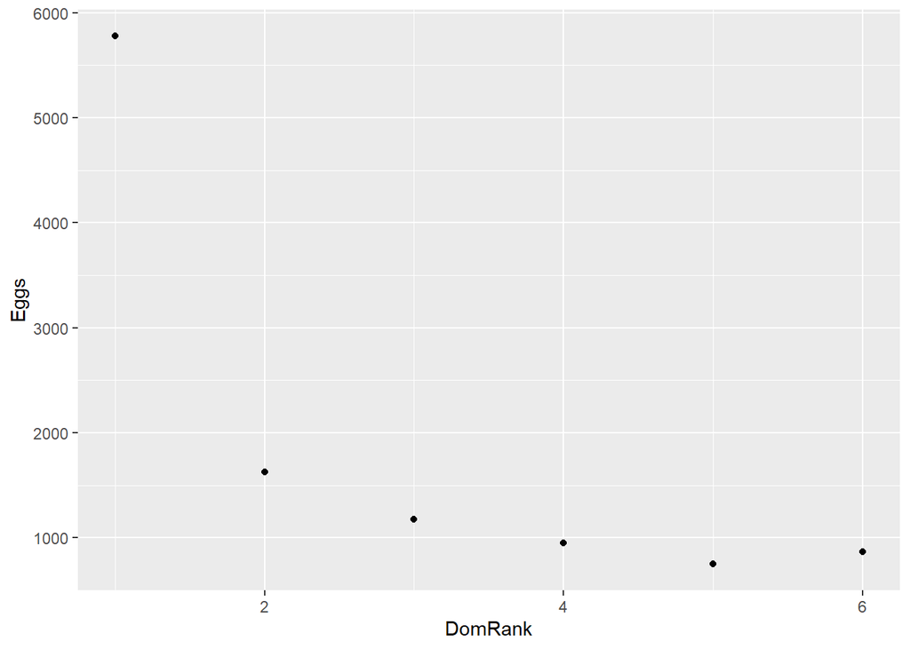

```r
monk <- ggplot(data= monke, aes(x = DomRank , y = Eggs))+ geom_point()
monk
```

```r
monke$Eggs <- log(monke$Eggs)
monke$DomRank <- log(monke$DomRank)
monke
```

```
##   Nr  Name   DomRank     Eggs
## 1  1  Alfa 0.0000000 8.661640
## 2  2  Beta 0.6931472 7.393263
## 3  3 Gamma 1.0986123 7.068172
## 4  4 Delta 1.3862944 6.855409
## 5  5 Theta 1.6094379 6.618739
## 6  6 Omega 1.7917595 6.768493
```

**Test:**

```r
comonke <- cor.test(monke$DomRank, monke$Eggs)
comonke
```

```
##
##  Pearson's product-moment correlation
##
## data:  monke$DomRank and monke$Eggs
## t = -6.4016, df = 4, p-value = 0.003058
## alternative hypothesis: true correlation is not equal to 0
## 95 percent confidence interval:
##  -0.9951688 -0.6342652
## sample estimates:
##        cor
## -0.9545015
```

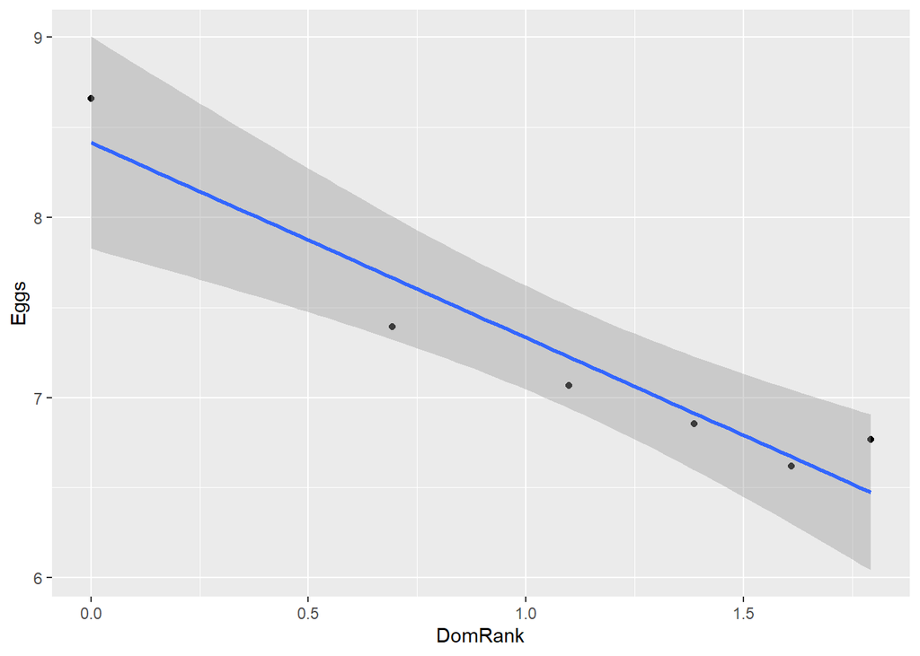

```r
ggplot(data= monke, aes(x = DomRank , y = Eggs))+ geom_point() + stat_smooth(method = lm)
```

**Wnioski:**  
Wartość p-value jest niższa niż 0.05, należy przyjąć hipotezę alternatywną: pozycja w rankingu dominacji małp jest związana ze stopniem zapasożycenia.

## Zadanie 4

**Hipoteza robocza:**  
Wielkość poroży jeleni rośnie zarówno z masą ciała jak i wiekiem byków.  
**Hipoteza zerowa:**  
Masą ciała oraz wiek byków nie wpływa na wielkość ich poroża.  
**Hipoteza alternatywna:**  
Wielkość poroży jeleni rośnie zarówno z masą ciała jak i wiekiem byków.  
**Testy “z wyboru”:**  
Analiza regresji.  
**Założenia teoretycznie dotyczące rozkładu wymagane dla wybranego testu:**  
Reszty mają rozkład zbliżony do rozkładu normalnego, liniowa zależność, równość wariancji.

```r
deer <- read.table(file = "Deer.txt",
                        sep = "\t",
                        header = T,
                        stringsAsFactors = T)
```

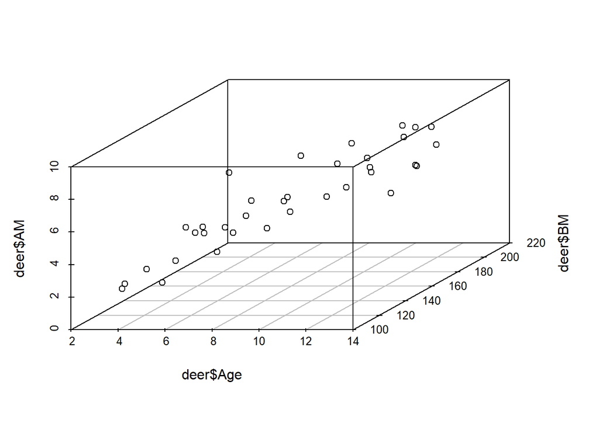

```r
deer1 <- ggplot(data = deer, aes(x = BM, y = AM)) + geom_point() + theme_classic()
deer2 <- ggplot(data = deer, aes(x = Age, y = AM)) + geom_point() + theme_classic()
deer3 <- ggplot(data = deer, aes(x = Age, y = BM)) + geom_point() + theme_classic()
plot3D <- scatterplot3d(deer$Age , deer$BM , deer$AM, angle=40)
```

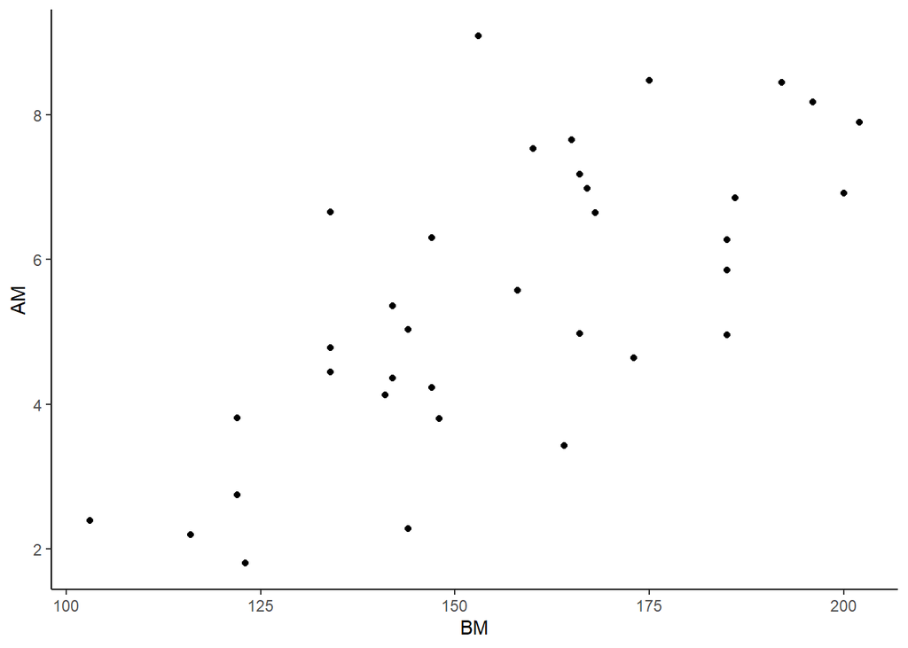

```r
deer1
```

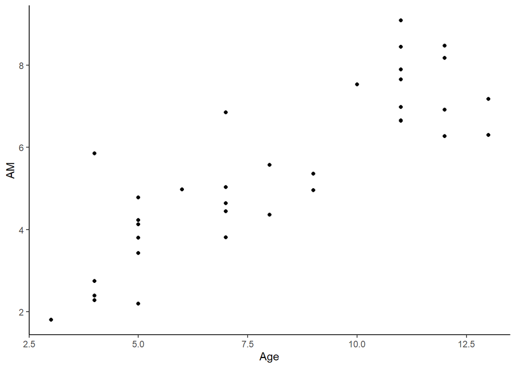

```r
deer2
```

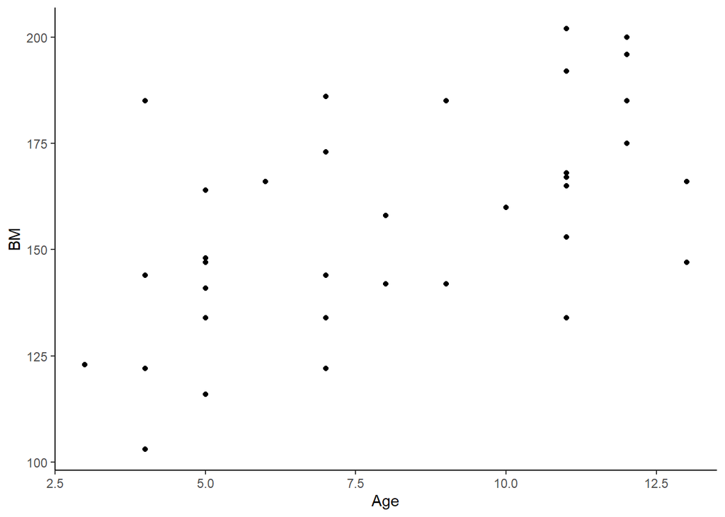

```r
deer3
```

**Testy:**

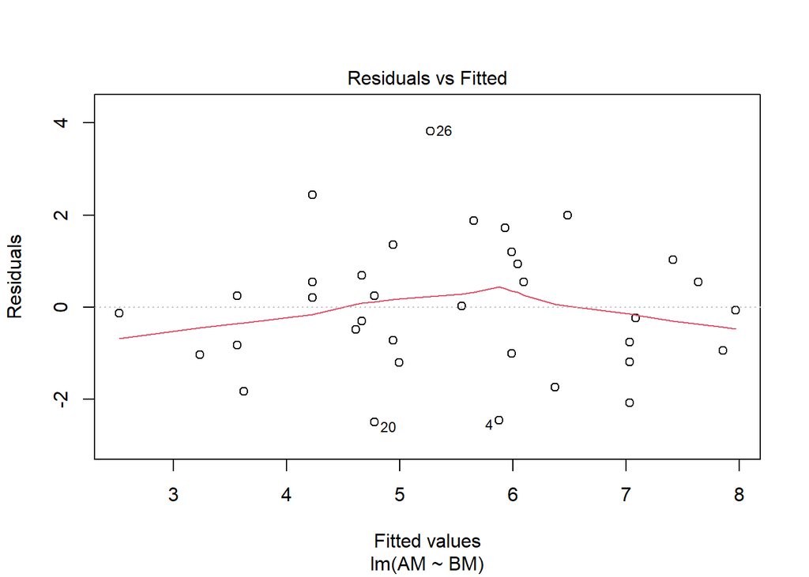

```r
reg1 <- lm( AM ~ BM , data = deer)
plot(reg1,1)
```

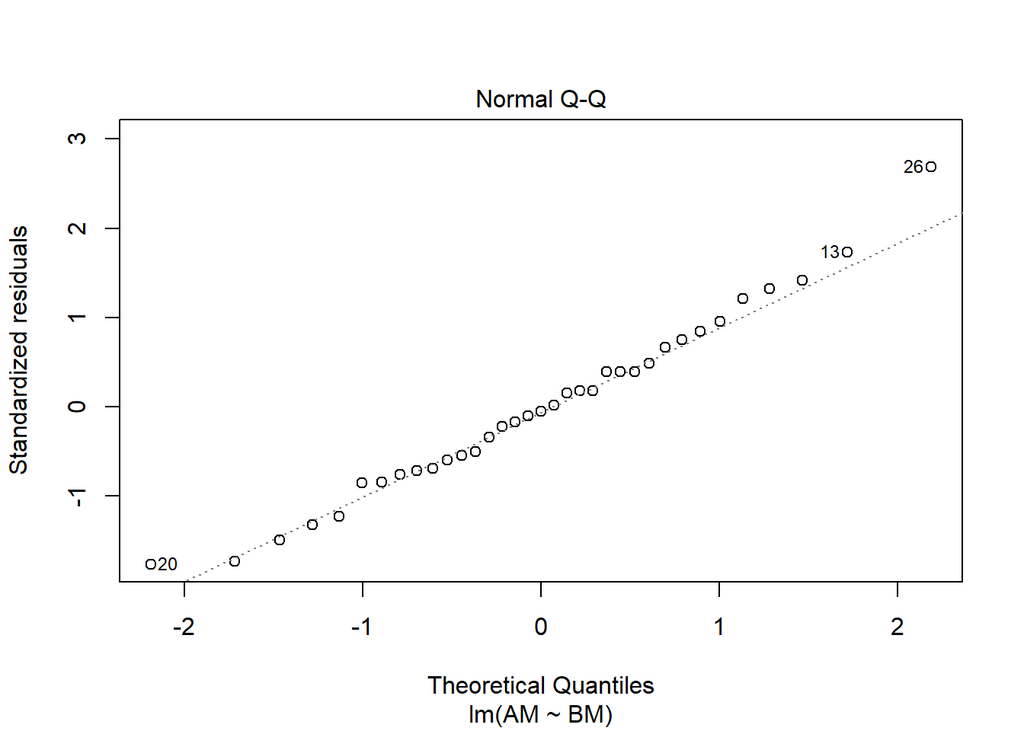

```r
plot(reg1,2)
```

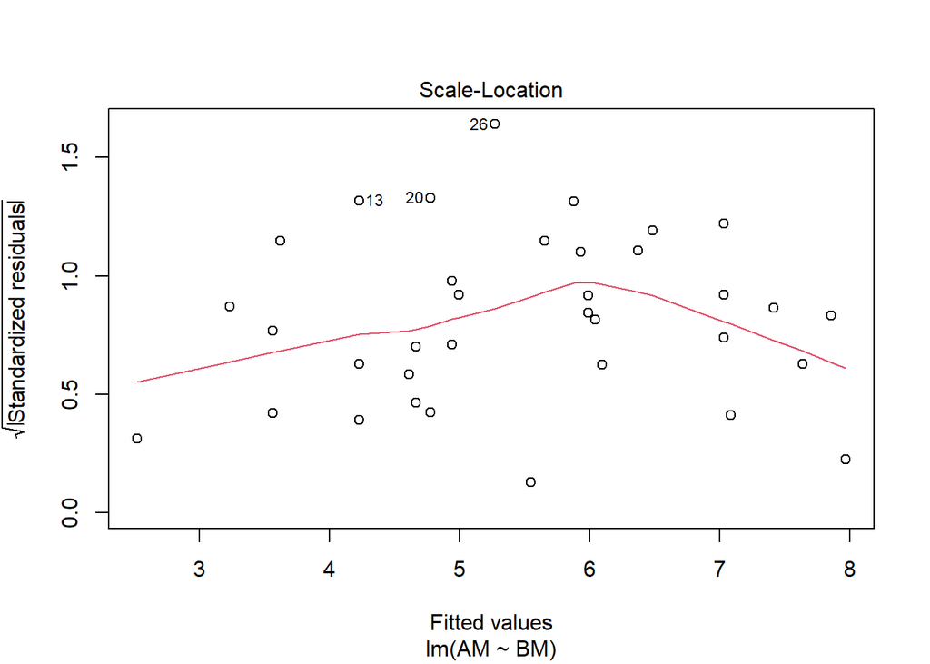

```r
plot(reg1,3)
```

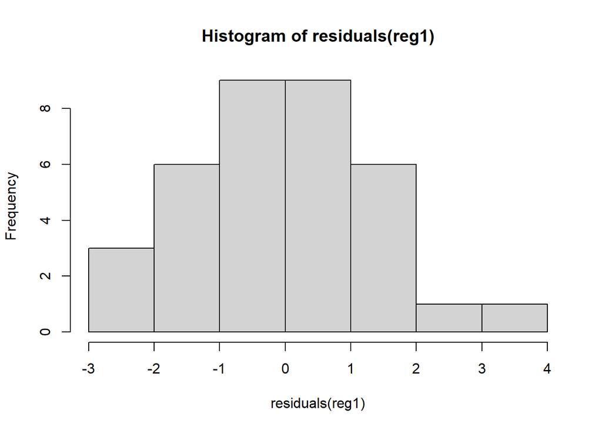

```r
hist(residuals(reg1))
```

```r
summary(reg1)
```

```
##
## Call:
## lm(formula = AM ~ BM, data = deer)
##
## Residuals:
##     Min      1Q  Median      3Q     Max
## -2.4964 -0.9724 -0.0679  0.8158  3.8184
##
## Coefficients:
##              Estimate Std. Error t value Pr(>|t|)
## (Intercept) -3.147488   1.541834  -2.041   0.0493 *
## BM           0.055027   0.009708   5.668 2.56e-06 ***
## ---
## Signif. codes:  0 '***' 0.001 '**' 0.01 '*' 0.05 '.' 0.1 ' ' 1
##
## Residual standard error: 1.441 on 33 degrees of freedom
## Multiple R-squared:  0.4933, Adjusted R-squared:  0.478
## F-statistic: 32.13 on 1 and 33 DF,  p-value: 2.565e-06
```

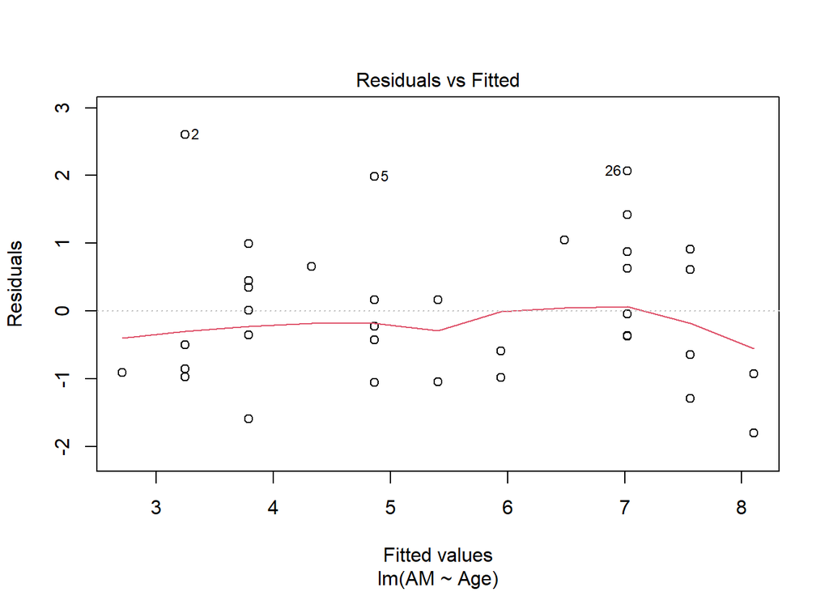

```r
reg2 <- lm( AM ~ Age , data = deer )
plot(reg2,1)
```

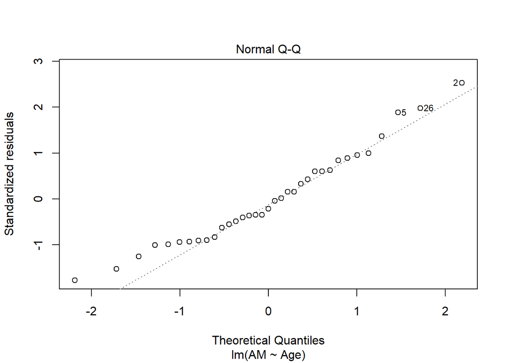

```r
plot(reg2,2)
```

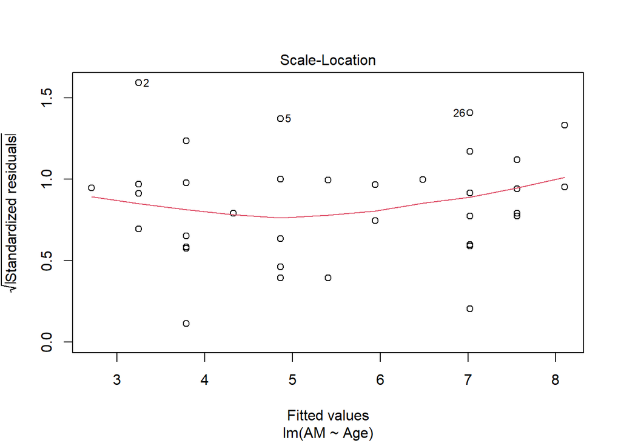

```r
plot(reg2,3)
```

```r
summary(reg2)
```

```
##
## Call:
## lm(formula = AM ~ Age, data = deer)
##
## Residuals:
##     Min      1Q  Median      3Q     Max
## -1.8033 -0.8819 -0.2256  0.6400  2.6033
##
## Coefficients:
##             Estimate Std. Error t value Pr(>|t|)
## (Intercept)  1.08821    0.51031   2.132   0.0405 *
## Age          0.53962    0.05859   9.210 1.22e-10 ***
## ---
## Signif. codes:  0 '***' 0.001 '**' 0.01 '*' 0.05 '.' 0.1 ' ' 1
##
## Residual standard error: 1.071 on 33 degrees of freedom
## Multiple R-squared:  0.7199, Adjusted R-squared:  0.7114
## F-statistic: 84.82 on 1 and 33 DF,  p-value: 1.22e-10
```

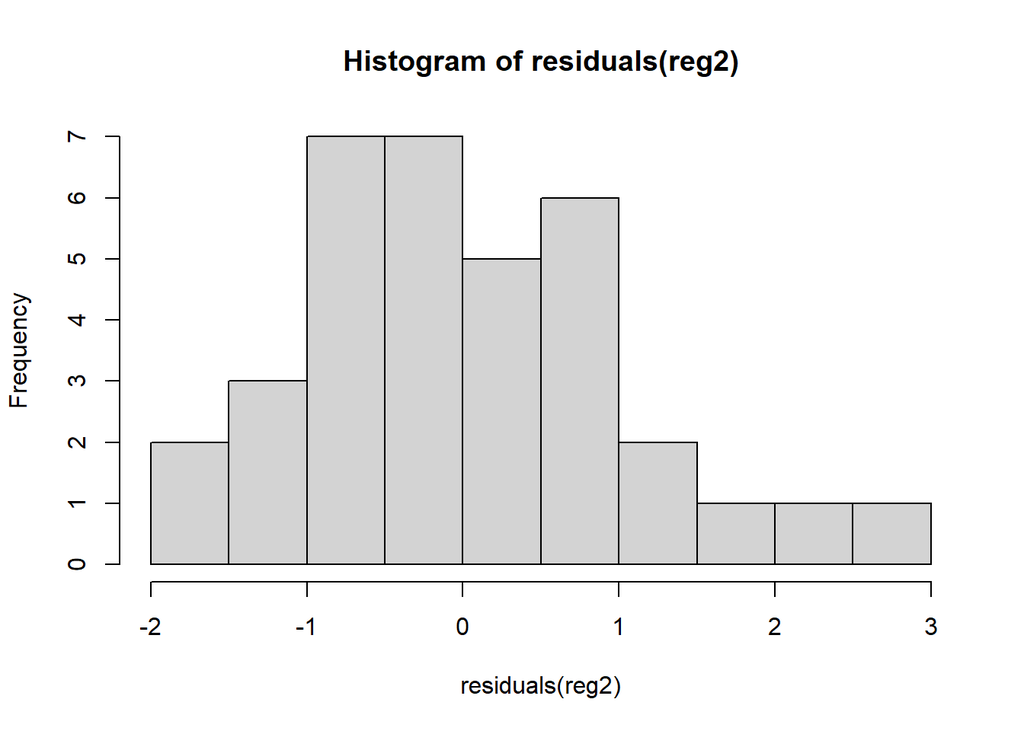

```r
hist(residuals(reg2))
```

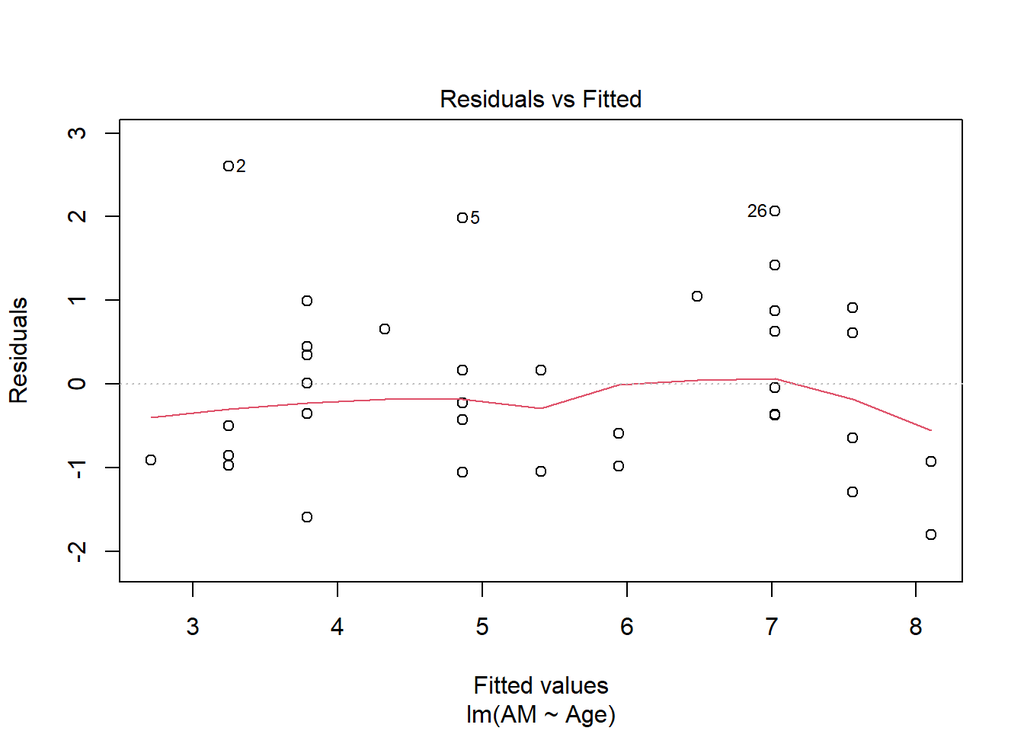

```r
reg3 <- lm( AM ~ BM + Age , data = deer )
plot(reg2,1)
```

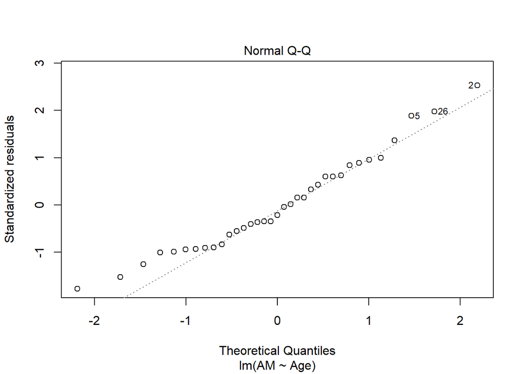

```r
plot(reg2,2)
```